# Trabalho Final - Acesso a bancos de dados abertos - Peixe-boi (Trichechus manatus)

Marina Valente S. Vermelho

2023-04-24

**Acesso a bancos de dados abertos - *Trichechus manatus***

Para realização deste trabalho utilizaremos os dados da espécie *Trichechus manatus*, popularmente conhecido como Peixe-boi marinho. Dentre os peixes-bois-marinhos são descritas duas subespécies: o peixe-boi-marinho-das-Antilhas *Trichechus manatus manatus* que ocorre na América Central e do Sul, e peixe-boi-marinho-da-Flórida *Trichechus manatus latirostris* que ocorre nos Estados Unidos (Luna, et al., 2011). Esta espécie ocorre em águas costeiras e em rios da região do Atlântico, do norte do Estado da Flórida (EUA), na costa leste do México e da América Central e norte da América do Sul, até o nordeste do Brasil, vive também em águas costeiras e estuários do Caribe e das Antilhas (Marsh, et al., 1986). No Brasil a espécie é considerada extinta nos Estados do Espírito Santo, Bahia e Sergipe (Albuquerque & Marcovaldi, 1982; Borobia & Lodi, 1992; Lima et al., 1992; Lima, 1997), sendo a atual área de ocorrência considerada entre os Estados de Alagoas até o Amapá, porém com áreas de descontinuidade em Alagoas, Pernambuco, Ceará (Lima, 1997; Alves, et al. 2015), Maranhão e Pará (Luna, 2001) contabilizando uma estimativa populacional total de cerca de 1000 animais (Luna, et al., 2018). A partir deste pressuposto utilizaremos as bases de dados GBIF (Global Biodiversity Information Facility) e OBIS (Ocean Biodiversity Information System) para buscar os registros de ocorrências desta espécie objetivando verificar se os dados corroboram com a literatura exposta.

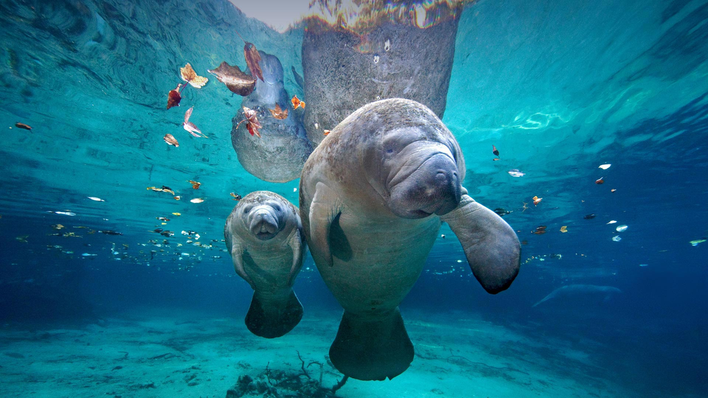

```r
knitr::include_graphics("D:/Doutorado/Imagens/PB2.jpg")
```

Para começar vamos baixar pacotes necessários e definir o diretório

```r
library('rgbif')
library('tidyverse')
library('bdc')
library('CoordinateCleaner')
library('ggmap')
```

```r
library('mapdata')
library('maps')
library('obistools')
library('devtools')
devtools::install_github('iobis/obistools')
setwd("D:/Doutorado/Disciplinas/Ciencia Colaborativa/Manatee")
```

O GBIF (Global Biodiversity Information Facility) será a primeira opção de repositório e Trichechus manatus a espécie utilizada

```r
# Checando as funcoes
?occ_data
```

```
## starting httpd help server ... done
```

```r
# Baixando ocorrencias de Trichechus manatus
manatee_gbif <- occ_data(scientificName = "Trichechus manatus",
                      hasCoordinate = TRUE,
                      hasGeospatialIssue=FALSE)

# Verficando as dimensoes do arquivo baixado
dim(manatee_gbif)
```

```r
# Verficando as dimensoes do arquivo baixado
dim(manatee_gbif$data)
```

```
## [1] 500 101
```

```r
# Checando os campos
manatee_gbif$data %>% names
```

```
##   [1] "key"                           "scientificName"
##   [3] "decimalLatitude"               "decimalLongitude"
##   [5] "issues"                        "datasetKey"
##   [7] "publishingOrgKey"              "installationKey"
##   [9] "publishingCountry"             "protocol"
##  [11] "lastCrawled"                   "lastParsed"
##  [13] "crawlId"                       "hostingOrganizationKey"
##  [15] "basisOfRecord"                 "occurrenceStatus"
##  [17] "taxonKey"                      "kingdomKey"
##  [19] "phylumKey"                     "classKey"
##  [21] "orderKey"                      "familyKey"
##  [23] "genusKey"                      "speciesKey"
##  [25] "acceptedTaxonKey"              "acceptedScientificName"
##  [27] "kingdom"                       "phylum"
##  [29] "order"                         "family"
```

[output cut: 36 more lines]

Utilizaremos a função **gbif_issues** para vizualisar os problemas desse conjunto de dados e a função **strsplit** para individualizar os issues e poder conferí-los.

```r
# checando problemas reportados
issues_gbif <- manatee_gbif$data$issues %>%
  unique() %>%
  strsplit(., "[,]") %>%
  unlist()

gbif_issues() %>%
  data.frame() %>%
  filter(code %in% issues_gbif)
```

```
##      code                                            issue
## 1     cdc               CONTINENT_DERIVED_FROM_COORDINATES
## 2 cdround                               COORDINATE_ROUNDED
## 3    cudc                 COUNTRY_DERIVED_FROM_COORDINATES
## 4   osiic OCCURRENCE_STATUS_INFERRED_FROM_INDIVIDUAL_COUNT
##                                                                                   description
## 1 The interpreted continent is based on the coordinates, not the verbatim string information.
## 2                                     Original coordinate modified by rounding to 5 decimals.
## 3   The interpreted country is based on the coordinates, not the verbatim string information.
## 4                              Occurrence status was inferred from the individual count value
##         type
## 1 occurrence
## 2 occurrence
## 3 occurrence
## 4 occurrence
```

Selecionamos algumas variáveis para a validação dos dados e futuras análises.

```r
manatee_gbif1 <- manatee_gbif$data %>%
  dplyr::select(scientificName, acceptedScientificName, decimalLatitude, decimalLongitude,
         issues, waterBody, basisOfRecord, occurrenceStatus, rightsHolder,
         datasetName, recordedBy, locality, continent, stateProvince)
```

Podemos ver que temos 500 ocorrências e 14 variáveis.

Vamos aplicar a função **distinct** do pacote **dplyr** para Visualizar quantas ocorrências são únicas.

```r
manatee_gbif1 <- manatee_gbif1 %>%
  distinct()
```

As 500 ocorrências foram mantidas.

Para identificar todos os valores únicos presented nos dados, vamos aplicar a função **unique** a cada coluna com um loop na função **lapply**.

```r
# checando niveis dos fatores
lapply(manatee_gbif1, unique)
```

```
## $scientificName
## [1] "Trichechus manatus Linnaeus, 1758"
## [2] "Trichechus manatus latirostris (Harlan, 1824)"
## [3] "Trichechus manatus manatus"
##
## $acceptedScientificName
## [1] "Trichechus manatus Linnaeus, 1758"
## [2] "Trichechus manatus latirostris (Harlan, 1824)"
## [3] "Trichechus manatus manatus"
##
## $decimalLatitude
##   [1] 28.779053 25.754614 25.704642 26.660174 27.717872 30.208023 25.601141
##   [8] 29.357752 29.288756 25.196597 26.165785 27.730450 28.847087 25.513337
##  [15] 25.432894 25.096825 25.678075 26.761849 25.725174 28.990171 28.972511
##  [22] 26.644877 26.608004 25.061145 27.796801 26.673727 26.737857 28.534415
```

[output cut: 907 more lines]

Utilizando as funções dos pacotes **CoordinateCleaner** e **bcd** podemos avaliar melhor os dados validando as coordenadas geográficas.

```r
# checando coordenadas válidas
check_pf <-
  bdc::bdc_coordinates_outOfRange(
    data = manatee_gbif1,
    lat = "decimalLatitude",
    lon = "decimalLongitude")
```

```
##
## bdc_coordinates_outOfRange:
## Flagged 0 records.
## One column was added to the database.
```

```r
# checando coordenadas válidas e próximas a capitais
cl <- manatee_gbif1 %>%
  select(acceptedScientificName, decimalLatitude, decimalLongitude) %>%
  rename(decimallongitude = decimalLongitude,
         decimallatitude = decimalLatitude,
         scientificName = acceptedScientificName) %>%
  as_tibble() %>%
  mutate(val = cc_val(., value = "flagged"),
         sea = cc_sea(., value = "flagged"),
         capital = cc_cap(., value = "flagged"))
```

```
## Testing coordinate validity
```

```
## Flagged 0 records.
```

```
## Testing sea coordinates
```

```
## Flagged 118 records.
```

```
## Testing country capitals
```

```
## Flagged 4 records.
```

Não tivemos nenhuma coordenada inválida.

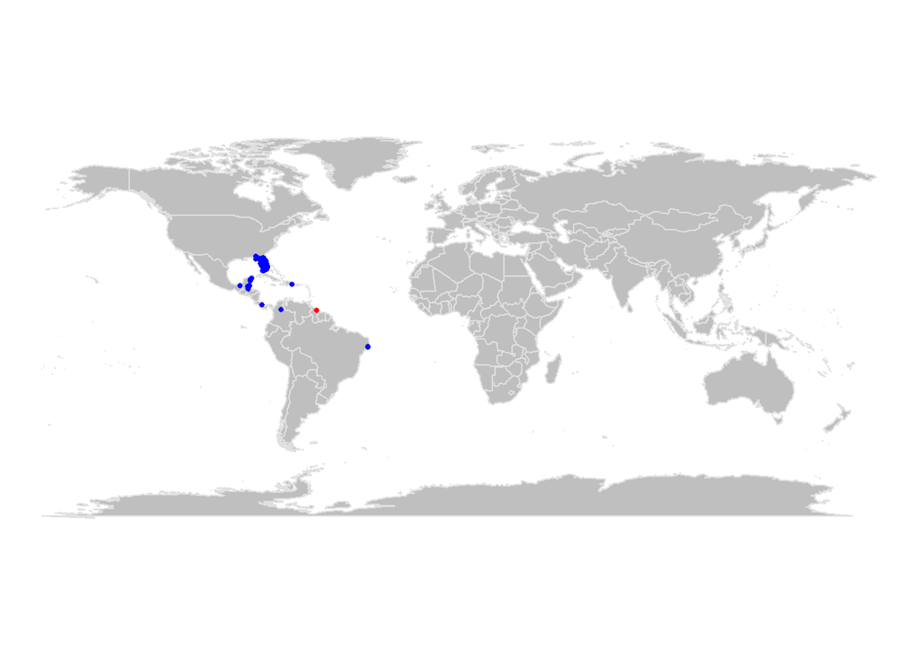

```r
# verificando coordenadas com flags

# capitais
cl %>%
  rename(decimalLongitude = decimallongitude,
         decimalLatitude = decimallatitude) %>%
  bdc::bdc_quickmap(., col_to_map = "capital")
```

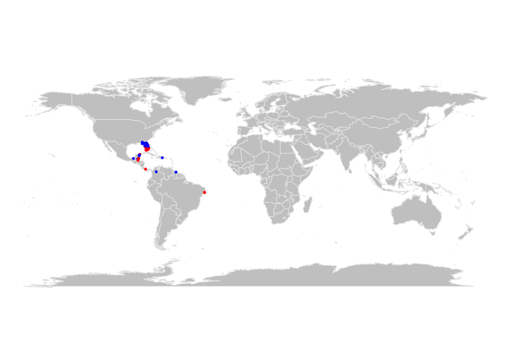

```r
cl %>%
  rename(decimalLongitude = decimallongitude,
         decimalLatitude = decimallatitude) %>%
  bdc::bdc_quickmap(., col_to_map = "sea")
```

Como não haviam dados para “waterbody” substitui essa variável por “stateProvince” para verificar se os estados ou municípios indicados eram área de ocorrência da espécie.

```r
# Aqui eu troquei waterbody para "stateProvince", pois "waterBody" estava como NA.
# investigar niveis suspeitos
manatee_gbif1 %>%
  distinct(stateProvince) %>%
  pull()
```

```
##  [1] "Florida"          NA                 "Quintana Roo"     "Stann Creek"
##  [5] "Orange Walk"      "Belize"           "Bocas del Toro"   "Toledo"
##  [9] "Corozal"          "Tabasco"          "Alagoas"          "Demerara-Mahaica"
## [13] "Santander"
```

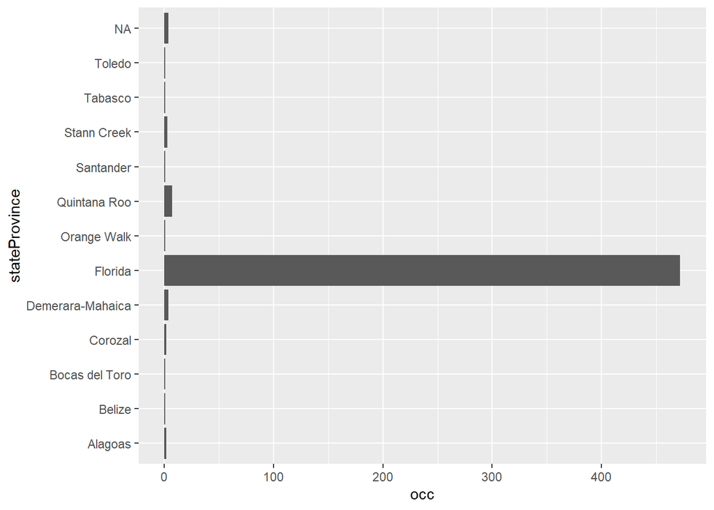

```r
# Aqui eu troquei waterbody para "stateProvince", pois "waterBody" estava como NA.
manatee_gbif1 %>%
  group_by(stateProvince) %>%
  summarise(occ = length(scientificName)) %>%
  ggplot(aes(occ, y=stateProvince)) +
    geom_bar(stat = 'identity')
```

Apareceram algumas localidades que não são de ocorrência da espécie e portanto resolvi checar as fontes erradas.

```r
# fonte das regioes erradas
manatee_gbif1 %>%
  filter(stateProvince %in% c("Corozal", "Orange Walk", "Santander", "Toledo")) %>%
  distinct(datasetName)
```

```
## # A tibble: 2 × 1
##   datasetName
##   <chr>
## 1 iNaturalist research-grade observations
## 2 <NA>
```

```r
# ocorrencias
manatee_gbif1 %>%
  filter(datasetName %in% c("iNaturalist research-grade observations"))
```

```
## # A tibble: 497 × 14
##    scientificName acceptedScientificName decimalLatitude decimalLongitude issues
##    <chr>          <chr>                            <dbl>            <dbl> <chr>
##  1 Trichechus ma… Trichechus manatus Li…            28.8            -80.7 cdc,c…
##  2 Trichechus ma… Trichechus manatus la…            25.8            -80.0 cdrou…
##  3 Trichechus ma… Trichechus manatus la…            25.7            -80.0 cdrou…
##  4 Trichechus ma… Trichechus manatus la…            26.7            -81.8 cdc,c…
##  5 Trichechus ma… Trichechus manatus la…            27.7            -82.6 cdc,c…
##  6 Trichechus ma… Trichechus manatus Li…            30.2            -84.3 cdc,c…
##  7 Trichechus ma… Trichechus manatus la…            25.6            -80.0 cdrou…
##  8 Trichechus ma… Trichechus manatus Li…            29.4            -82.0 cdc,c…
##  9 Trichechus ma… Trichechus manatus Li…            29.3            -82.1 cdc,c…
## 10 Trichechus ma… Trichechus manatus la…            25.2            -80.9 cdc,c…
## # ℹ 487 more rows
## # ℹ 9 more variables: waterBody <chr>, basisOfRecord <chr>,
## #   occurrenceStatus <chr>, rightsHolder <chr>, datasetName <chr>,
## #   recordedBy <chr>, locality <chr>, continent <chr>, stateProvince <chr>
```

```r
# filtrando todas do dataset suspeito
manatee_gbif_ok <- manatee_gbif1 %>%
  filter(!datasetName %in% c("iNaturalist research-grade observations"))
```

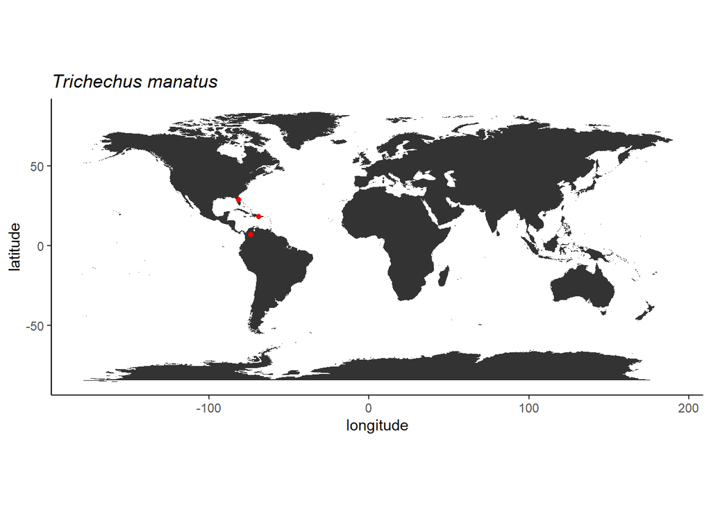

```r
world <- map_data('world')

# checando pontos

ggplot() +
  geom_polygon(data = world, aes(x = long, y = lat, group = group)) +
  coord_fixed() +
  theme_classic() +
  geom_point(data = manatee_gbif_ok, aes(x = decimalLongitude, y = decimalLatitude), color = "red") +
  labs(x = "longitude", y = "latitude", title = expression(italic("Trichechus manatus")))
```

Ao realizar este filtro a maior parte das ocorrencias não apareceram, pois possuiam a mesma fonte das localidades pertinentes.

Agora vamos fazer os mesmos procedimentos com os dados do OBIS, utilizando o pacote **robis** e a função **occurrence** deste pacote.

```r
# OBIS
manatee_obis <- robis::occurrence("Trichechus manatus")
```

```
##
Retrieved 5000 records of approximately 30447 (16%)
Retrieved 10000 records of
## approximately 30447 (32%)
Retrieved 15000 records of approximately 30447
## (49%)
Retrieved 20000 records of approximately 30447 (65%)
Retrieved 25000
## records of approximately 30447 (82%)
Retrieved 30000 records of approximately
## 30447 (98%)
Retrieved 30447 records of approximately 30447 (100%)
```

```r
# checando dados
names(manatee_obis)
```

```
##   [1] "date_year"                     "scientificNameID"
##   [3] "scientificName"                "individualCount"
##   [5] "associatedReferences"          "dropped"
##   [7] "aphiaID"                       "decimalLatitude"
##   [9] "subclassid"                    "type"
##  [11] "taxonRemarks"                  "phylumid"
##  [13] "familyid"                      "catalogNumber"
##  [15] "occurrenceStatus"              "basisOfRecord"
##  [17] "terrestrial"                   "superclass"
##  [19] "modified"                      "id"
##  [21] "order"                         "infraspecificEpithet"
##  [23] "recordNumber"                  "georeferencedDate"
##  [25] "superclassid"                  "verbatimEventDate"
##  [27] "dataset_id"                    "decimalLongitude"
##  [29] "collectionCode"                "date_end"
```

[output cut: 57 more lines]

```r
manatee_obis1 <- manatee_obis %>%
  dplyr::select(scientificName, decimalLatitude, decimalLongitude, bathymetry,
         flags, waterBody, basisOfRecord, occurrenceStatus, rightsHolder,
         datasetName, recordedBy, depth, locality, habitat, continent, stateProvince) %>%
  distinct()

# check problemas reportados (flags)
manatee_obis1 %>%
  distinct(flags)
```

```
## # A tibble: 6 × 1
##   flags
##   <chr>
## 1 NO_DEPTH
## 2 NO_DEPTH,ON_LAND
## 3 ON_LAND,NO_DEPTH
## 4 <NA>
## 5 ON_LAND
## 6 DEPTH_EXCEEDS_BATH,ON_LAND
```

```r
# check NA em datasetName
manatee_obis1 %>%
  filter(!flags %in% c("no_depth,on_land", "on_land", "on_land,depth_exceeds_bath", "depth_exceeds_bath,on_land"),
         is.na(datasetName)) %>%
  distinct(waterBody)
```

```
## # A tibble: 3 × 1
##   waterBody
##   <chr>
## 1 Gulf of Mexico
## 2 <NA>
## 3 South Atlantic
```

```r
# checando niveis
manatee_obis1 %>%
  filter(!flags %in% c("no_depth,on_land", "on_land", "on_land,depth_exceeds_bath", "depth_exceeds_bath,on_land"),
         !is.na(datasetName),
         !waterBody %in% c("North America", "South America")) %>%
  lapply(., unique)
```

```
## $scientificName
## [1] "Trichechus manatus latirostris" "Trichechus manatus"
## [3] "Trichechus manatus manatus"
##
## $decimalLatitude
##     [1] 26.676088 26.774265 26.763340 19.906300 26.525045 27.574680 26.136938
##     [8] 25.556635 25.815881 26.355514 26.575359 26.524250 26.688815 28.892773
##    [15] 27.190480 25.537045 27.001196 25.551710 26.059548 26.698846 25.851500
##    [22] 28.853980 26.770965 28.395288 26.775357 28.316000 27.793357 28.074626
##    [29] 28.895106 29.596607 26.783138 25.556045 26.084145 26.518430 28.070590
##    [36] 25.958185 26.691329 25.106976 26.567305 26.993865 28.328840 27.300678
##    [43] 26.938825 27.833895 27.986770 26.885710 28.029818 27.172595 25.367895
##    [50] 25.787728 26.762655 27.792975 26.543407 26.381483 28.293471 26.577775
##    [57] 26.077240 26.951565 25.949594 26.691035 25.947787 26.688155 28.468447
##    [64] 27.992798 25.113120 28.374235 29.161631 19.912000 27.759347 26.076329
```

[output cut: 8217 more lines]

```r
# ok
manatee_obis_ok <- manatee_obis1 %>%
  filter(!flags %in% c("no_depth,on_land", "on_land", "on_land,depth_exceeds_bath", "depth_exceeds_bath,on_land"),
         !is.na(datasetName),
         !waterBody %in% c("North America", "South America"))
```

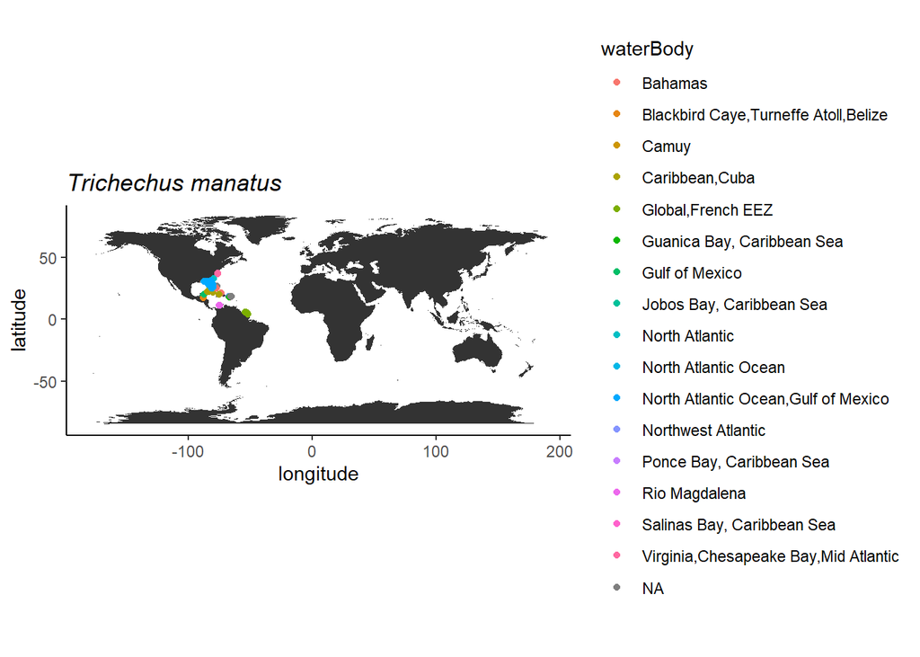

```r
# check
ggplot() +
  geom_polygon(data = world, aes(x = long, y = lat, group = group)) +
  coord_fixed() +
  theme_classic() +
  geom_point(data = manatee_obis_ok, aes(x = decimalLongitude, y = decimalLatitude, color = waterBody)) +
  labs(x = "longitude", y = "latitude", title = expression(italic("Trichechus manatus")))
```

O mapa permite visualizar as ocorrencias após os filtros.

Vamos unir os resultados obtidos com o GBIF e OBIS.

```r
# unindo GBIF e OBIS

# vendo diferencas
setdiff(names(manatee_gbif_ok), names(manatee_obis_ok))
```

```
## [1] "acceptedScientificName" "issues"
```

```r
setdiff(names(manatee_obis_ok), names(manatee_gbif_ok))
```

```
## [1] "bathymetry" "flags"      "depth"      "habitat"
```

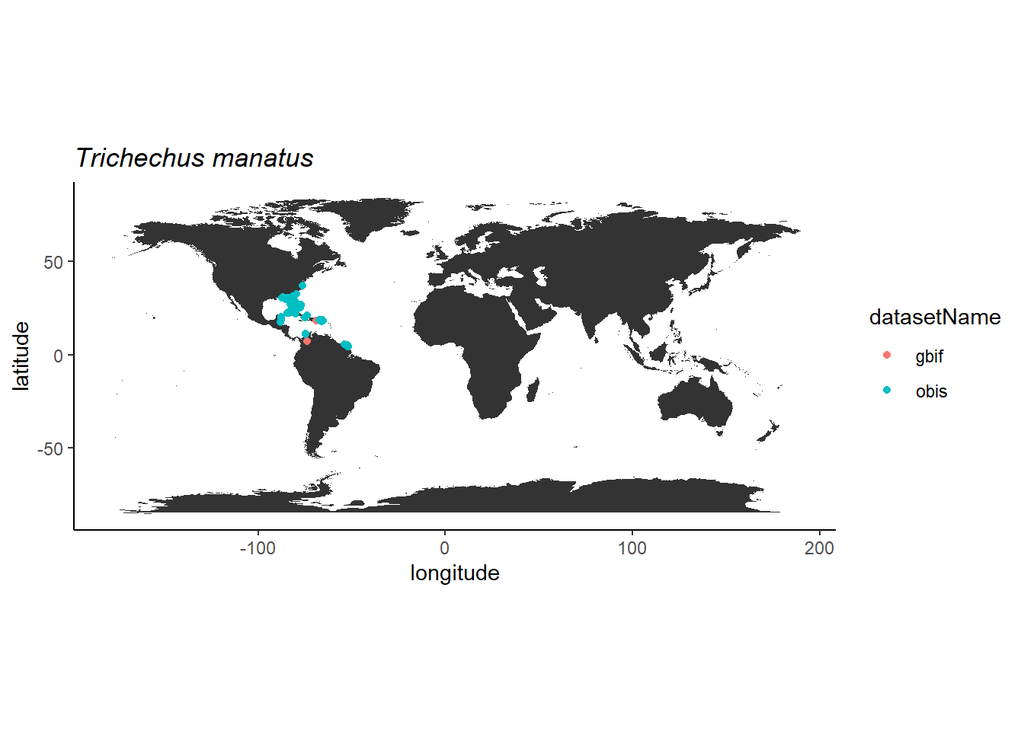

```r
all_data <- bind_rows(manatee_gbif_ok %>%
                        mutate(repo = paste0("gbif", row.names(.))),
                      manatee_obis_ok %>%
                        mutate(repo = paste0("obis", row.names(.)))) %>%
  column_to_rownames("repo") %>%
  dplyr::select(decimalLongitude, decimalLatitude, depth) %>%
  distinct() %>%
  rownames_to_column("occ") %>%
  separate(col = "occ", into = c("datasetName", "rn"), sep = 4) %>%
  mutate(scientificName = "Trichechus manatus") %>%
  dplyr::select(-rn)


# mapeando ocorrencias
ggplot() +
  geom_polygon(data = world, aes(x = long, y = lat, group = group)) +
  coord_fixed() +
  theme_classic() +
  geom_point(data = all_data, aes(x = decimalLongitude, y = decimalLatitude, color = datasetName)) +
  #theme(legend.title = element_blank()) +
  labs(x = "longitude", y = "latitude", title = expression(italic("Trichechus manatus")))
```

**Considerações Finais**

O mapa final permitiu observar que os dados de ocorrencia da espécie *Trichechus manatus* corroboram em parte com a literatura exposta previamente, e ainda apontam uma lacuna existente, ou ausência de dados de ocorrencia da espécie no Brasil. Concluindo que são necessários maiores estudos de orreência para esta espécie ou compartilhamento dos dados encontrados em bases de dados abertos.

Exportando planilha final

```r
write.csv(all_data, "D:/Doutorado/Disciplinas/Ciencia Colaborativa/Manatee/occ_GBIF-OBIS_Trichechus_manatus.csv", row.names = FALSE)
```

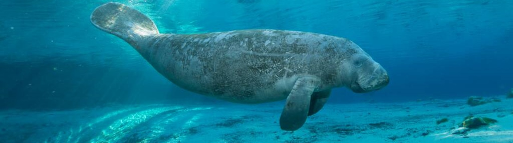

```r
knitr::include_graphics("D:/Doutorado/Imagens/PB.jpg")
```